# Transforming and analyzing data

Andrew Ba Tran

This is from the [third chapter](https://learn.r-journalism.com/en/wrangling/dplyr/dplyr/) of [learn.r-journalism.com](https://learn.r-journalism.com/).

Why use **dplyr**?

- Designed to work with data frames, which is what journalists are used to
- Great for data exploration and transformation
- Intuitive to write and easy to read, especially when using the “chaining” syntax of pipes

## Five basic verbs

- `filter()`
- `select()`
- `arrange()`
- `mutate()`
- `summarize()` plus `group_by()`

## Our data

We’re going to be wrangling some pretty big data– murders over decades across the country.

This case-level data was acquired by the [Murder Accountability Project](http://www.murderdata.org/p/data-docs.html) from the Justice Department.

We’re going to use the basics of **dplyr** verb functions to analyze the data and see if there are any stories there might be worth pursuing.

Remember that huge SPSS data set we imported in the previous chapter?

I saved all that code we wrote to import it, renaming columns, and joining values and labels into an R script: *import_murders.R*. This is reproducibility in action.

Check out [what it looks like](https://github.com/r-journalism/learn-chapter-3/blob/master/dplyr/import_murders.R)– it’s about 100 lines of code long but only one line is required to run the script below.

**Warning**: Before running the command, make sure the script is in the working directory folder and that the **SHR76_16.sav.zip** file is in the *data* sub folder. For example, on my computer, the *import_murders.R* script is in the *dplyr* folder and **SHR76_16.sav.zip** file is in the *dplyr/data* folder.

**This is going to take a few minutes to run.**

```r
source("import_murders.R")
```

Alright, the **import_murders.R** script unzipped data, imported it, and transformed it into a workable dataframe and saved it to our environment as the object **murders** for us to analyze. You probably got some warnings in the console but that’s okay.

```
View(murders)
```

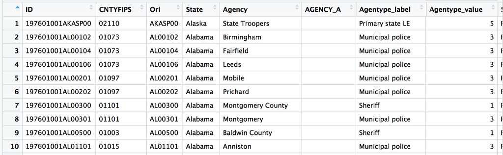

Here’s the [data dictionary](https://www.dropbox.com/s/lo6tgo8nnbpqeru/MAPdefinitionsSHR.pdf?dl=1).

What are we dealing with here?

## Number of rows (cases)?

```r
nrow(murders)
```

```
## [1] 752313
```

## How many municipalities?

We’ll use a couple base R functions: `unique()` and `length()`.

```r
# Make a list of cities based on the unique() function
how_many <- unique(murders$MSA_label)

# Count up how many are in the list
length(how_many)
```

```
## [1] 409
```

Whew, let’s not overwhelm ourselves with all this data as we’re getting started out.

When I get a new data set I like to see what it’s made of. So I can begin to get a sense of how to summarize it or take it apart.

Start with the `glimpse()` function from **dplyr**– it will give a brief look at the variables in the data set and the data type.

```r
glimpse(murders)
```

```
## Observations: 752,313
## Variables: 47
## $ ID                 <fct> 197601001AKASP00, 197601001AL00102, 1976010...
## $ CNTYFIPS           <fct> 02110          , 01073          , 01073    ...
## $ Ori                <fct> AKASP00, AL00102, AL00104, AL00106, AL00201...
## $ State              <fct> Alaska, Alabama, Alabama, Alabama, Alabama,...
## $ Agency             <fct> State Troopers                             ...
## $ AGENCY_A           <fct>                                            ...
## $ Agentype_label     <fct> Primary state LE, Municipal police, Municip...
## $ Agentype_value     <dbl> 5, 3, 3, 3, 3, 3, 1, 3, 1, 3, 3, 3, 3, 3, 3...
## $ Source_label       <fct> FBI, FBI, FBI, FBI, FBI, FBI, FBI, FBI, FBI...
## $ Source_value       <dbl> 1, 1, 1, 1, 1, 1, 1, 1, 1, 1, 1, 1, 1, 1, 1...
## $ Solved_label       <fct> Yes, Yes, Yes, Yes, Yes, Yes, Yes, Yes, Yes...
## $ Solved_value       <dbl> 1, 1, 1, 1, 1, 1, 1, 1, 1, 1, 1, 1, 1, 1, 1...
## $ Year               <dbl> 1976, 1976, 1976, 1976, 1976, 1976, 1976, 1...
```

[output cut: 34 more lines]

Then, I’ll go through the variables that interest me to see how many types there are. The more variables (columns) you have in a data set that are categorical, the deeper you can dive in analyzing it.

For example, if you had a data set with a list of salaries (1 variable) you could:

- Figure out the median salary
- Calculate the difference between the highest and the lowest salaries

If you had a data set with salaries and gender of worker (2 variables) you could additionally:

- Figure out median salary for men and women
- Calculate the differences in those medians

If you had a data set with salaries and gender of worker and state where they live (3 variables) you could additionally:

- Find out median salary per state
- Figure out median salary for men and women per state
- Determine which state had the biggest disparity
- See which state women get paid more than men

Let’s narrow down our scope by using the `filter()` function.

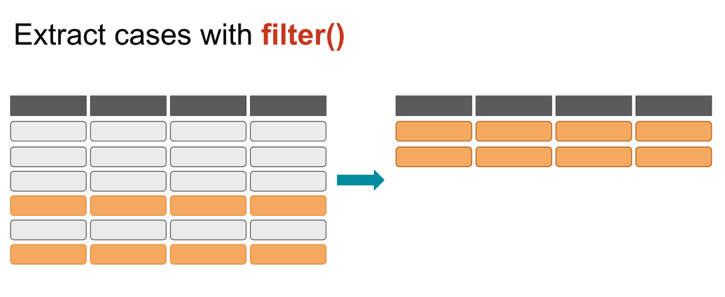

Filter works by extracting rows that meet a criteria you set.

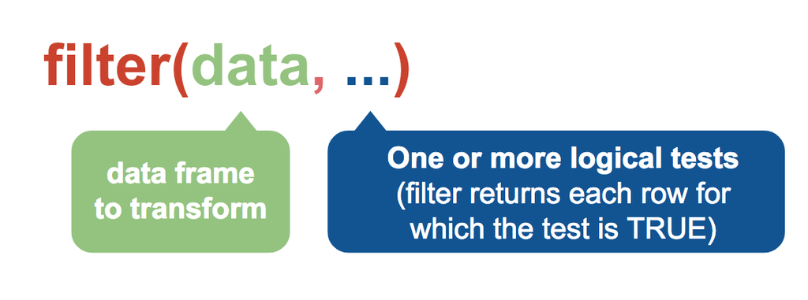

You pass the dataframe as a variable to `filter()` first and then you add any logical tests.

**Warning**: One `=` in R is the same as `<-` in that it assigns a value. Logical tests requires two, so `==` which tests for equal.

```r
df1 <- filter(murders, Relationship_label=="Husband", VicAge > 60, Year==2016)

# same as the line above
df2 <- filter(murders, Relationship_label=="Husband" & VicAge > 60 & Year==2016)

df3 <- filter(murders, Relationship_label %in% c("Husband", "Boyfriend") |
                Circumstance_label=="Lovers triangle")
```

Check out the new objects in the Environment window of RStudio.

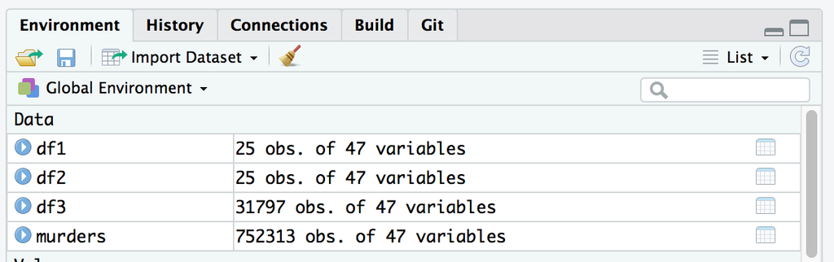

Data frames df1 and df2 are exactly the same (Looking for cases in which Husbands were involved, the victim was older than 60, and occurred in 2016)– only 25 were found. Meanwhile d3 has nearly 32,000 cases in which a Husband or Boyfriend were involved or it was labeled by investigators as a lover’s triangle.

## Logical Operators

| Operator | Description |
| --- | --- |
| `<` | Less than |
| `<=` | Less than or equal to |
| `>` | Greater than |
| `>=` | Greater than or equal to |
| `==` | Exactly equal to |
| `!=` | Not equal to |
| `!x` | Not x |
| `x \| y` | x or y |
| `x & y` | x and y |
| `%in%` | Group membership |
| `isTRUE(x)` | Test if x is TRUE |
| `is.na(x)` | Test if x is NA |
| `!is.na(x)` | Test if x is not NA |

**Test yourself**

**Common mistakes**

1. Using `=` instead of `==`

```
# WRONG
filter(murders, fstate_label="District of Columbia")

# RIGHT
filter(murders, fstate_label=="District of Columbia")
```

2. Forgetting quotes

```
# WRONG
filter(murders, fstate_label=District of Columbia)

# RIGHT
filter(murders, fstate_label="District of Columbia"")
```

3. Collapsing multiple tests into one

```
# WRONG
filter(murders, 1980 < year < 1990)

# RIGHT
filter(murders, 1980 < year, year < 1990)
```

4. Stringing together many tests instead of using %in%

```
# Not WRONG but INEFFICIENT to type out
filter(murders, VicRace_label=="Black" | VicRace_label="Unknown" |
  VicRace_label=="Asian or Pacific Islander")

# RIGHT
filter(murders, VicRace_label %in% c("Black", "Unknown", "Asian or Pacific Islander"))
```

We have 47 variables (aka columns) and we don’t need all of them for this basic analysis. Let’s narrow that down.

## select()

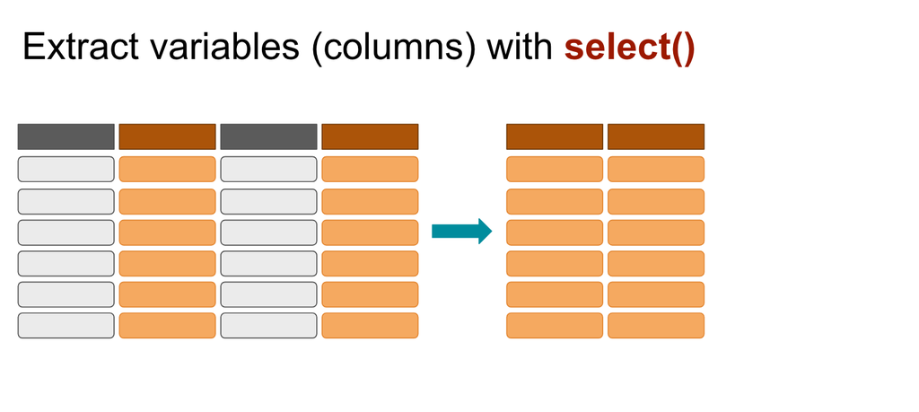

You simply list the column names after the data frame you want to extract from.

```r
df1_narrow <- select(df1, State, Agency, Solved_label, Year)
```

```
View(df1_narrow)
```

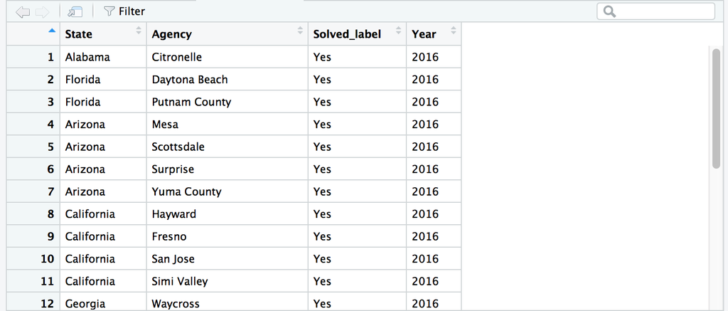

You can use a colon between column names if you want all the columns between.

```r
df2_narrow <- select(df1, State, OffAge:OffRace_value, Weapon_label)
```

```
View(df2_narrow)
```

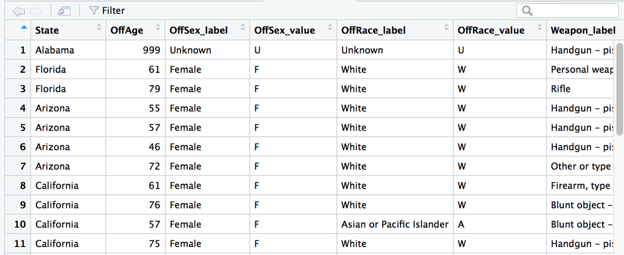

Use a `-` next to a column name to drop it (You can drop more than one column at a time, too).

```r
# modifying the data frame created above
df3_narrow <- select(df2_narrow, -Weapon_label)
```

```
View(df3_narrow)
```

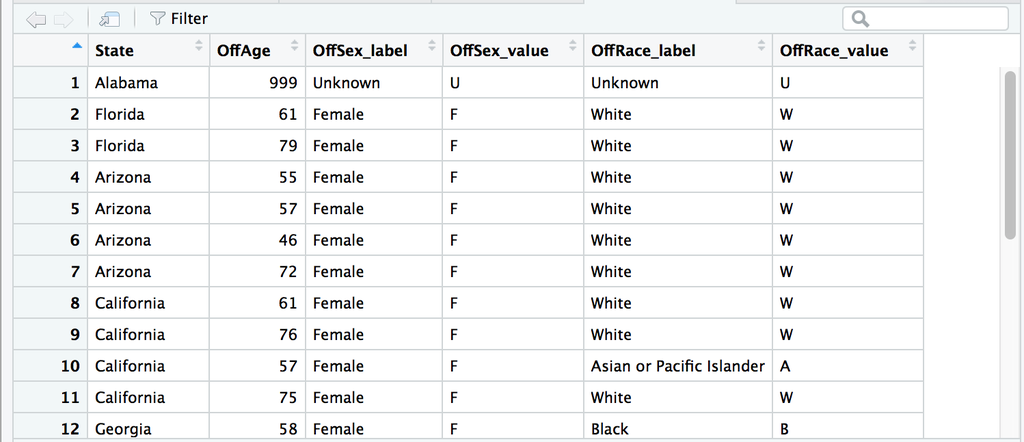

There are so many other functions you can use with `select()` to help make your life easier.

```
# This extracts all variables with names that contain "_label"

labels_only_columns <- select(murders(contains("_label")))
str(labels_only_columns)
```

Check out all the neat `select()` options [here](https://dplyr.tidyverse.org/reference/select_helpers.html).

Great, let’s move on to the next verb.

## arrange()

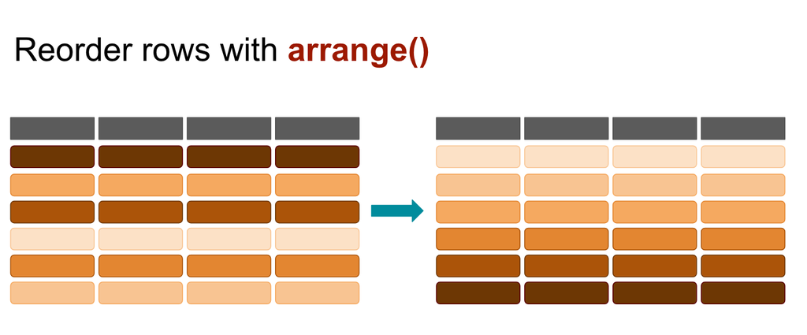

You can include more than one variable (column)– the first one will take priority but subsequent variables will serve as tie breakers.

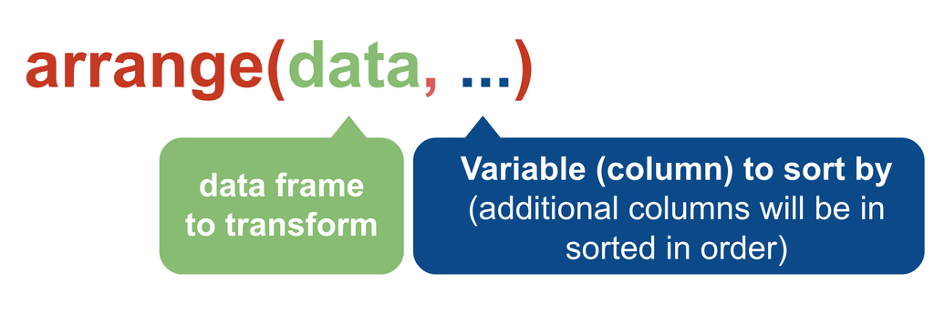

```r
age_df1 <- arrange(murders, VicAge)

age_df2 <- arrange(murders, VicAge, OffAge)

age_df3 <- arrange(murders, VicAge, desc(OffAge))

# Same result as above
age_df3b <- arrange(murders, VicAge, -OffAge)
```

This will be very useful. Let’s move on to the next verb.

## mutate()

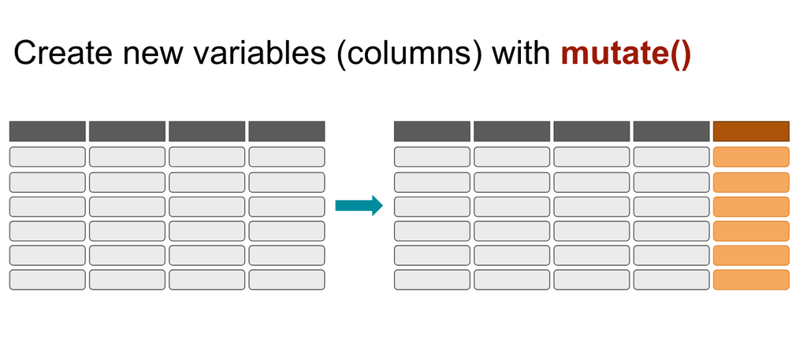

We can create new variables (new columns) with the `mutate()` function.

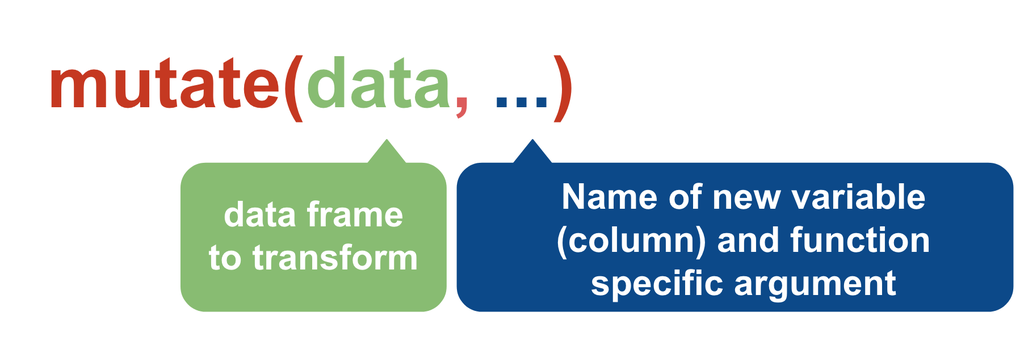

```r
murders_ver2 <- mutate(murders,
                       age_difference=OffAge-VicAge)
```

```
View(murders_ver2)
```

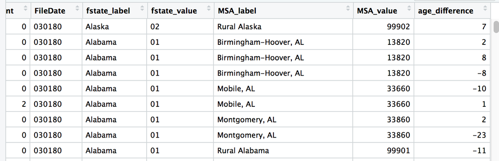

## Arithmetic Operators

| Operator | Description |
| --- | --- |
| `+` | Addition |
| `-` | Subtraction |
| `*` | Multiplication |
| `/` | Division |
| `^` | Exponentiation |

You can do more than just math in the context of `mutate()`.

You can use `case_when()` in `mutate()` to create new values based on other values, kind of like an if_else statement.

```r
# creates an age_difference column
# and creates a vic_category column that is populated with values
# depending on the VicRace_label column

murders_ver3 <- mutate(murders,
                       age_difference=OffAge-VicAge,
                       vic_category=case_when(
                         VicRace_label == "White" ~ "White",
                         VicRace_label != "White" ~ "Non-White"
                       ))
```

**Tip**: This is the first of a few times you’ll see the `~` (tilde) operator. It means it’s a one-sided formula, usually in statistical model formulas. It can be described as “[depends on](https://stackoverflow.com/questions/14976331/use-of-tilde-in-r-programming-language)” You don’t need to really to understand why a tilde is necessary– only that this is how this particular function needs to be set up to work successfully.

There are two variables being created in the `mutate()` function separated by commas.

- one is **age_difference** which just subtracts the values in **OffAge** and **VicAge**.
- the other is **vic_category** that is either assigned “White” or “Non-White” depending on if the value of the column **VicRace_label** is “White” or *not* “White”.

```
View(murders_ver3)
```

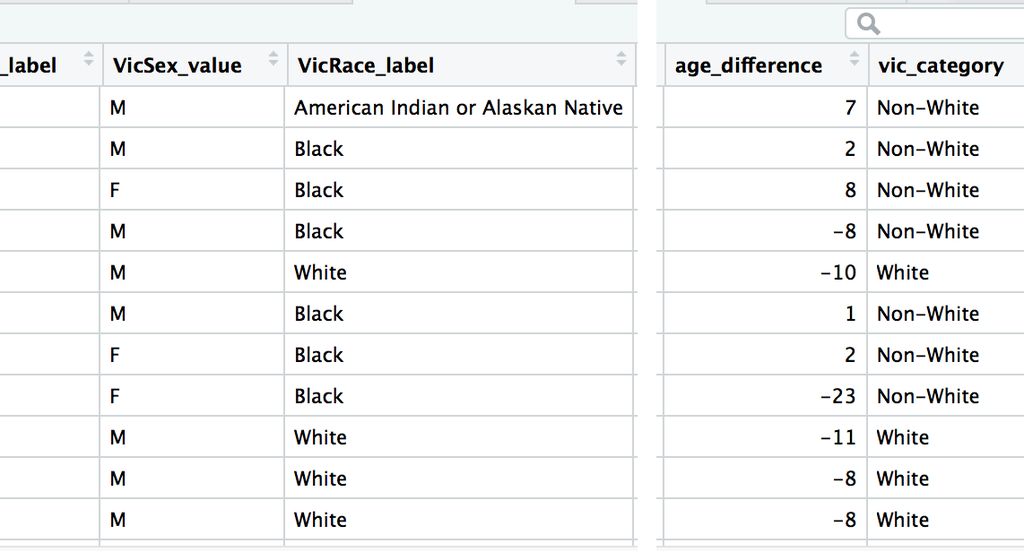

This is an example of a vectorized function in action. There are some really great ones like `lag()` and `lead()` and `rank()` and we might get into them later. In the meantime, here’s a [neat list](https://dplyr.tidyverse.org/reference/mutate.html#useful-functions).

## Rename

You can rename variables (columns) easily with the function `rename()`

```r
colnames(df3_narrow)
```

```
## [1] "State"         "OffAge"        "OffSex_label"  "OffSex_value"
## [5] "OffRace_label" "OffRace_value"
```

```r
# OK, you see the column names above-- let's change a couple of them

df3_renamed <- rename(df3_narrow,
                      offender_gender=OffSex_label,
                      offender_age=OffAge)
colnames(df3_renamed)
```

```
## [1] "State"           "offender_age"    "offender_gender" "OffSex_value"
## [5] "OffRace_label"   "OffRace_value"
```

You can also rename variables (columns) with the `select()` function. This is just a way to cut down on extra lines of code

```r
colnames(df3_narrow)
```

```
## [1] "State"         "OffAge"        "OffSex_label"  "OffSex_value"
## [5] "OffRace_label" "OffRace_value"
```

```r
# Keeping only the State and offender gender and age columns but renaming the
# OffSex_label and OffAge columns

df4_renamed <- select(df3_narrow,
                      State,
                      offender_gender=OffSex_label,
                      offender_age=OffAge)

df4_renamed
```

```
##             State offender_gender offender_age
## 1         Alabama         Unknown          999
## 2         Florida          Female           61
## 3         Florida          Female           79
## 4         Arizona          Female           55
## 5         Arizona          Female           57
## 6         Arizona          Female           46
## 7         Arizona          Female           72
## 8      California          Female           61
## 9      California          Female           76
## 10     California          Female           57
## 11     California          Female           75
## 12        Georgia          Female           58
## 13       Kentucky          Female           77
## 14       Kentucky          Female           67
## 15       Michigan          Female           72
## 16       Michigan          Female           72
## 17    Mississippi          Female           46
## 18     New Mexico            Male           83
## 19       Oklahoma          Female           58
## 20   Pennsylvania          Female           57
## 21  Rhodes Island          Female           57
## 22 South Carolina          Female           72
## 23 South Carolina          Female           76
## 24      Tennessee          Female           63
## 25          Texas          Female           71
```

## summarize()

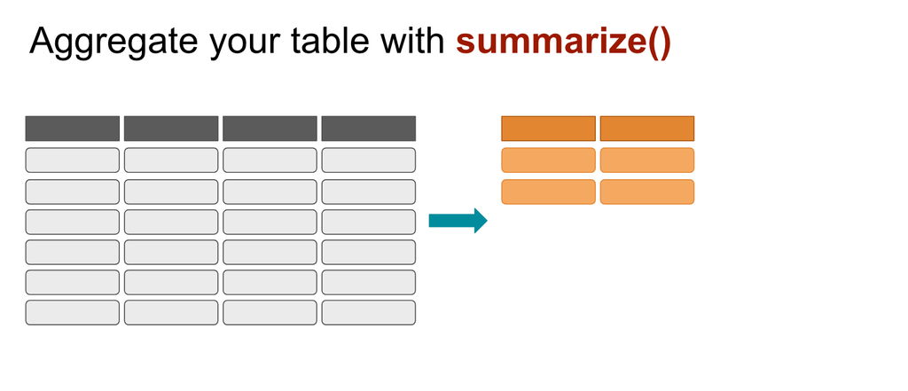

This is the equivalent of creating a pivot table in Excel.

You’re aggregating the whole table into something simplified.

```r
summarize(murders, average_victim_age=mean(VicAge))
```

```
##   average_victim_age
## 1           47.96203
```

You can create a table of summaries.

```r
summarize(murders,
          average_victim_age=mean(VicAge),
          average_offender_age=mean(OffAge))
```

```
##   average_victim_age average_offender_age
## 1           47.96203             352.7295
```

**Warning**: There’s something wrong with the average_offender_age value. Can you figure out what happened?

Summarize the data frame **murders**

```r
summarize(murders,
          first=min(Year),
          last=max(Year),
          metro_areas=n_distinct(MSA_label),
          cases=n())
```

```
##   first last metro_areas  cases
## 1  1976 2016         409 752313
```

## group_by()

You can aggregate data by groups before summarizing.

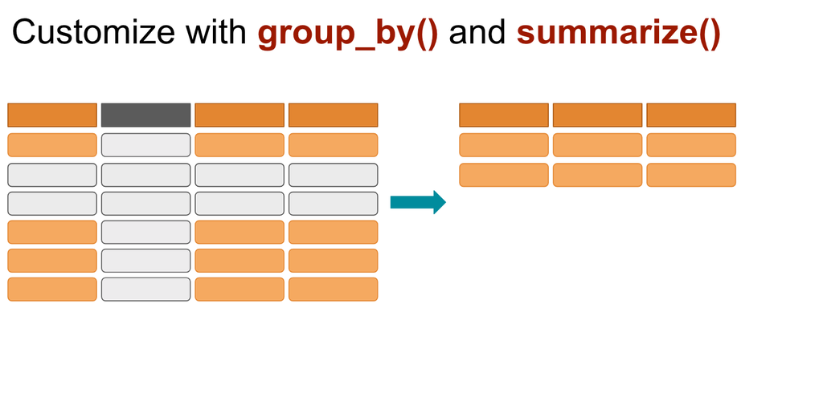

```r
# This is the same process as before but we're telling R to group up
# the metro areas before summarizing the data

murders <- group_by(murders, MSA_label)

summarize(murders,
          first=min(Year),
          last=max(Year),
          cases=n())
```

```
## # A tibble: 409 x 4
##    MSA_label                         first  last cases
##    <fct>                             <dbl> <dbl> <int>
##  1 Abilene, TX                        1976  2016   366
##  2 Akron, OH                          1976  2016  1080
##  3 Albany, GA                         1976  2016   633
##  4 Albany-Schenectady-Troy, NY        1976  2016   829
##  5 Albuquerque, NM                    1976  2016  2374
##  6 Alexandria, LA                     1976  2016   576
##  7 Allentown-Bethlehem-Easton, PA-NJ  1976  2016   882
##  8 Altoona, PA                        1976  2016   120
##  9 Amarillo, TX                       1976  2016   724
## 10 Ames, IA                           1978  2016    26
## # ... with 399 more rows
```

This might be a tough concept to fully understand at first, but we’ll go over a few more examples soon so it will hopefully make more sense.

Also, I want to point out that the opposite of `group_by()` is `ungroup()` which you might need later on as you progress.

But let’s get over some very useful functionality that comes with the **dplyr** package.

## pipe %>%

Data analyses will most often involve more than one step.

We’re going to over some **options** on how to approach multi-step processes with this data set and then we’ll go over the *best* way to deal with them.

Description of theoretical process to run on the **murders** data frame:

1. **Extract rows** for cases that happened in Washington DC, then
2. **Group** case by year and then
3. **Count** the number of cases
4. **Arrange** the by decreasing cases

**Option 1**

Build out a new dataframe for each step.

```r
dc_annual_murders1 <- filter(murders, State=="District of Columbia")
dc_annual_murders2 <- group_by(dc_annual_murders1, Year)
dc_annual_murders3 <- summarize(dc_annual_murders2, total=n())
dc_annual_murders4 <- arrange(dc_annual_murders3, desc(total))

# looking at the first 6 rows of data

head(dc_annual_murders4)
```

```
## # A tibble: 6 x 2
##    Year total
##   <dbl> <int>
## 1  1991   489
## 2  1990   481
## 3  1992   450
## 4  1989   439
## 5  1993   423
## 6  1994   417
```

**Option 2**

Do it all in one line by nesting functions.

```r
dc_annual_murders <- arrange(
  summarize(
    group_by(
      filter(murders, State=="District of Columbia"),
      Year),
    total=n()),
  desc(total))

# looking at the first 6 rows of data

head(dc_annual_murders)
```

```
## # A tibble: 6 x 2
##    Year total
##   <dbl> <int>
## 1  1991   489
## 2  1990   481
## 3  1992   450
## 4  1989   439
## 5  1993   423
## 6  1994   417
```

These options aren’t great because the first one involves just way too much typing, even if it’s pretty clear to an outside reader what’s happening to the data frame. The second one is no good because, while it’s efficient with coding, it’s way too difficult to follow what’s happening to the data.

Let’s talk about the pipe operator `%>%`

You might have noticed that all the functions from **dplyr** all structured similarly: *The first argument is always the data frame.*

It takes in a data frame and spits out a data frame.

This function structure is what allows for something like the `%>%` to work.

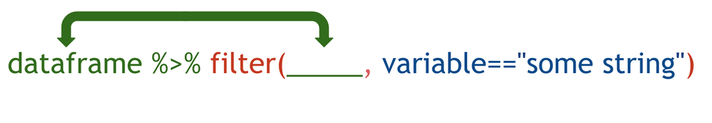

These commands do the same thing. Give it a try.

```r
filter(murders, OffAge==2)
```

```
## # A tibble: 3 x 47
## # Groups:   MSA_label [3]
##   ID    CNTYFIPS Ori   State Agency AGENCY_A Agentype_label Agentype_value
##   <fct> <fct>    <fct> <fct> <fct>  <fct>    <fct>                   <dbl>
## 1 1977… "13121 … GA06… Geor… "East… "      … Municipal pol…              3
## 2 1979… "36061 … NY03… New … "New … "      … Municipal pol…              3
## 3 2015… "18089 … IN04… Indi… "Gary… "      … Municipal pol…              3
## # ... with 39 more variables: Source_label <fct>, Source_value <dbl>,
## #   Solved_label <fct>, Solved_value <dbl>, Year <dbl>, Month_label <fct>,
## #   Month_value <dbl>, Incident <dbl>, ActionType <fct>,
## #   Homicide_label <fct>, Homicide_value <fct>, Situation_label <fct>,
## #   Situation_value <fct>, VicAge <dbl>, VicSex_label <fct>,
## #   VicSex_value <fct>, VicRace_label <fct>, VicRace_value <fct>,
## #   VicEthnic <fct>, OffAge <dbl>, OffSex_label <fct>, OffSex_value <fct>,
## #   OffRace_label <fct>, OffRace_value <fct>, OffEthnic <fct>,
## #   Weapon_label <fct>, Weapon_value <dbl>, Relationship_label <fct>,
## #   Relationship_value <fct>, Circumstance_label <fct>,
## #   Circumstance_value <dbl>, Subcircum <fct>, VicCount <dbl>,
## #   OffCount <dbl>, FileDate <fct>, fstate_label <fct>,
## #   fstate_value <fct>, MSA_label <fct>, MSA_value <dbl>
```

```r
murders %>% filter(OffAge==2)
```

```
## # A tibble: 3 x 47
## # Groups:   MSA_label [3]
##   ID    CNTYFIPS Ori   State Agency AGENCY_A Agentype_label Agentype_value
##   <fct> <fct>    <fct> <fct> <fct>  <fct>    <fct>                   <dbl>
## 1 1977… "13121 … GA06… Geor… "East… "      … Municipal pol…              3
## 2 1979… "36061 … NY03… New … "New … "      … Municipal pol…              3
## 3 2015… "18089 … IN04… Indi… "Gary… "      … Municipal pol…              3
## # ... with 39 more variables: Source_label <fct>, Source_value <dbl>,
## #   Solved_label <fct>, Solved_value <dbl>, Year <dbl>, Month_label <fct>,
## #   Month_value <dbl>, Incident <dbl>, ActionType <fct>,
## #   Homicide_label <fct>, Homicide_value <fct>, Situation_label <fct>,
## #   Situation_value <fct>, VicAge <dbl>, VicSex_label <fct>,
## #   VicSex_value <fct>, VicRace_label <fct>, VicRace_value <fct>,
## #   VicEthnic <fct>, OffAge <dbl>, OffSex_label <fct>, OffSex_value <fct>,
## #   OffRace_label <fct>, OffRace_value <fct>, OffEthnic <fct>,
## #   Weapon_label <fct>, Weapon_value <dbl>, Relationship_label <fct>,
## #   Relationship_value <fct>, Circumstance_label <fct>,
## #   Circumstance_value <dbl>, Subcircum <fct>, VicCount <dbl>,
## #   OffCount <dbl>, FileDate <fct>, fstate_label <fct>,
## #   fstate_value <fct>, MSA_label <fct>, MSA_value <dbl>
```

In essence, a `%>%` is the grammatical equivalent of *and then…*.

Again, a description of the theoretical process:

- **Extract rows** for cases that happened in Washington DC, then
- **Group** case by year and then
- **Count** the number of cases
- **Arrange** the by decreasing cases

**Option 3**

Use the `%>%` pipe

```r
filter(murders, State=="District of Columbia") %>%
  group_by(Year) %>%
  summarize(total=n()) %>%
  arrange(desc(total)) %>%
  head()
```

```
## # A tibble: 6 x 2
##    Year total
##   <dbl> <int>
## 1  1991   489
## 2  1990   481
## 3  1992   450
## 4  1989   439
## 5  1993   423
## 6  1994   417
```

So readable and simple, right?

Here’s the shortcut to type `%>%` in RStudio:

- Mac: Cmd + Shift + M
- Windows: Ctrl + Shift + M

Why “M”? I think it’s because the pipe was first introduced in the [**magrittr** package](https://cran.r-project.org/web/packages/magrittr/README.html) by Stefan Milton Bache.